# ANCOVA in TDE - Escrita (TDE - Escrita)

Geiser C. Challco geiser@alumni.usp.br

- Descriptive Statistics of Initial Data
- ANCOVA and Pairwise for one factor: **grupo**
  - Without remove non-normal data
  - Computing ANCOVA and PairWise After removing non-normal data (OK)
    - Plots for ancova
    - Checking linearity assumption
    - Checking normality and homogeneity
- ANCOVA and Pairwise for two factors **grupo:Sexo**
  - Without remove non-normal data
  - Computing ANCOVA and PairWise After removing non-normal data (OK)
    - Plots for ancova
    - Checking linearity assumption
    - Checking normality and homogeneity
- ANCOVA and Pairwise for two factors **grupo:Zona**
  - Without remove non-normal data
  - Computing ANCOVA and PairWise After removing non-normal data (OK)
    - Plots for ancova
    - Checking linearity assumption
    - Checking normality and homogeneity
- ANCOVA and Pairwise for two factors **grupo:Cor.Raca**
  - Without remove non-normal data
  - Computing ANCOVA and PairWise After removing non-normal data (OK)
    - Plots for ancova
    - Checking linearity assumption
    - Checking normality and homogeneity
- ANCOVA and Pairwise for two factors **grupo:score.tde.quintile**
  - Without remove non-normal data
  - Computing ANCOVA and PairWise After removing non-normal data (OK)
    - Plots for ancova
    - Checking linearity assumption
    - Checking normality and homogeneity
- Summary of Results
  - Descriptive Statistics
  - ANCOVA Table Comparison
  - PairWise Table Comparison
  - EMMS Table Comparison

**NOTE**:

- Teste ANCOVA para determinar se houve diferenças significativas no TDE - Escrita (medido usando pre- e pos-testes).
- ANCOVA test to determine whether there were significant differences in TDE - Escrita (measured using pre- and post-tests).

# Descriptive Statistics of Initial Data

```r
df <- get.descriptives(dat, c(dv.pre, dv.pos), c("grupo"),
                       include.global = T, symmetry.test = T, normality.test = F)
df <- plyr::rbind.fill(
  df, do.call(plyr::rbind.fill, lapply(lfatores2, FUN = function(f) {
    if (nrow(dat) > 0 && sum(!is.na(unique(dat[[f]]))) > 1)
      get.descriptives(dat, c(dv.pre,dv.pos), c("grupo", f),
                       symmetry.test = T, normality.test = F)
    }))
)
(df <- df[,c(fatores1[fatores1 %in% colnames(df)],"variable",
             colnames(df)[!colnames(df) %in% c(fatores1,"variable")])])
```

```
##           grupo Sexo   Zona Cor.Raca score.tde.quintile      variable   n   mean median min max     sd    se
## 1      Controle <NA>   <NA>     <NA>               <NA> score.tde.pre 141 34.716   41.0   0  69 17.842 1.503
## 2  Experimental <NA>   <NA>     <NA>               <NA> score.tde.pre 187 36.540   38.0   0  68 14.891 1.089
## 3          <NA> <NA>   <NA>     <NA>               <NA> score.tde.pre 328 35.756   38.0   0  69 16.225 0.896
## 4      Controle <NA>   <NA>     <NA>               <NA> score.tde.pos 141 28.362   22.0   0  72 20.646 1.739
## 5  Experimental <NA>   <NA>     <NA>               <NA> score.tde.pos 187 33.524   36.0   0  69 17.147 1.254
## 6          <NA> <NA>   <NA>     <NA>               <NA> score.tde.pos 328 31.305   30.0   0  72 18.875 1.042
## 7      Controle    F   <NA>     <NA>               <NA> score.tde.pre  80 37.675   42.0   0  65 16.826 1.881
## 8      Controle    M   <NA>     <NA>               <NA> score.tde.pre  61 30.836   31.0   0  69 18.521 2.371
## 9  Experimental    F   <NA>     <NA>               <NA> score.tde.pre  88 37.841   39.0   0  68 13.887 1.480
## 10 Experimental    M   <NA>     <NA>               <NA> score.tde.pre  99 35.384   35.0   6  65 15.710 1.579
## 11     Controle    F   <NA>     <NA>               <NA> score.tde.pos  80 30.262   25.5   0  72 20.809 2.326
## 12     Controle    M   <NA>     <NA>               <NA> score.tde.pos  61 25.869   21.0   0  68 20.330 2.603
## 13 Experimental    F   <NA>     <NA>               <NA> score.tde.pos  88 36.227   39.0   0  67 16.312 1.739
## 14 Experimental    M   <NA>     <NA>               <NA> score.tde.pos  99 31.121   33.0   0  69 17.590 1.768
```

[output cut: 98 more lines]

| grupo | Sexo | Zona | Cor.Raca | score.tde.quintile | variable | n | mean | median | min | max | sd | se | ci | iqr | symmetry | skewness | kurtosis |
| --- | --- | --- | --- | --- | --- | --- | --- | --- | --- | --- | --- | --- | --- | --- | --- | --- | --- |
| Controle |  |  |  |  | score.tde.pre | 141 | 34.716 | 41.0 | 0 | 69 | 17.842 | 1.503 | 2.971 | 29.00 | YES | -0.265 | -1.162 |
| Experimental |  |  |  |  | score.tde.pre | 187 | 36.540 | 38.0 | 0 | 68 | 14.891 | 1.089 | 2.148 | 21.50 | YES | -0.195 | -0.682 |
|  |  |  |  |  | score.tde.pre | 328 | 35.756 | 38.0 | 0 | 69 | 16.225 | 0.896 | 1.762 | 25.00 | YES | -0.268 | -0.865 |
| Controle |  |  |  |  | score.tde.pos | 141 | 28.362 | 22.0 | 0 | 72 | 20.646 | 1.739 | 3.437 | 37.00 | YES | 0.379 | -1.190 |
| Experimental |  |  |  |  | score.tde.pos | 187 | 33.524 | 36.0 | 0 | 69 | 17.147 | 1.254 | 2.474 | 27.50 | YES | -0.063 | -0.934 |
|  |  |  |  |  | score.tde.pos | 328 | 31.305 | 30.0 | 0 | 72 | 18.875 | 1.042 | 2.050 | 32.00 | YES | 0.112 | -1.116 |
| Controle | F |  |  |  | score.tde.pre | 80 | 37.675 | 42.0 | 0 | 65 | 16.826 | 1.881 | 3.744 | 24.25 | YES | -0.484 | -0.799 |
| Controle | M |  |  |  | score.tde.pre | 61 | 30.836 | 31.0 | 0 | 69 | 18.521 | 2.371 | 4.744 | 33.00 | YES | 0.038 | -1.397 |
| Experimental | F |  |  |  | score.tde.pre | 88 | 37.841 | 39.0 | 0 | 68 | 13.887 | 1.480 | 2.942 | 18.50 | YES | -0.244 | -0.407 |
| Experimental | M |  |  |  | score.tde.pre | 99 | 35.384 | 35.0 | 6 | 65 | 15.710 | 1.579 | 3.133 | 22.50 | YES | -0.116 | -0.917 |
| Controle | F |  |  |  | score.tde.pos | 80 | 30.262 | 25.5 | 0 | 72 | 20.809 | 2.326 | 4.631 | 38.50 | YES | 0.292 | -1.320 |
| Controle | M |  |  |  | score.tde.pos | 61 | 25.869 | 21.0 | 0 | 68 | 20.330 | 2.603 | 5.207 | 32.00 | YES | 0.489 | -1.042 |
| Experimental | F |  |  |  | score.tde.pos | 88 | 36.227 | 39.0 | 0 | 67 | 16.312 | 1.739 | 3.456 | 23.50 | YES | -0.223 | -0.809 |
| Experimental | M |  |  |  | score.tde.pos | 99 | 31.121 | 33.0 | 0 | 69 | 17.590 | 1.768 | 3.508 | 28.00 | YES | 0.104 | -0.980 |
| Controle |  | Rural |  |  | score.tde.pre | 69 | 33.739 | 42.0 | 0 | 69 | 19.266 | 2.319 | 4.628 | 34.00 | YES | -0.236 | -1.367 |
| Controle |  | Urbana |  |  | score.tde.pre | 55 | 36.036 | 38.0 | 1 | 64 | 15.821 | 2.133 | 4.277 | 22.00 | YES | -0.309 | -0.751 |
| Controle |  |  |  |  | score.tde.pre | 17 | 34.412 | 33.0 | 6 | 60 | 18.788 | 4.557 | 9.660 | 34.00 | YES | -0.026 | -1.770 |
| Experimental |  | Rural |  |  | score.tde.pre | 87 | 35.287 | 35.0 | 8 | 68 | 14.454 | 1.550 | 3.081 | 20.50 | YES | -0.043 | -0.795 |
| Experimental |  | Urbana |  |  | score.tde.pre | 75 | 38.280 | 41.0 | 0 | 65 | 15.835 | 1.828 | 3.643 | 21.00 | YES | -0.404 | -0.514 |
| Experimental |  |  |  |  | score.tde.pre | 25 | 35.680 | 37.0 | 14 | 58 | 13.450 | 2.690 | 5.552 | 22.00 | YES | -0.118 | -1.226 |
| Controle |  | Rural |  |  | score.tde.pos | 69 | 33.971 | 31.0 | 0 | 72 | 22.239 | 2.677 | 5.342 | 40.00 | YES | -0.010 | -1.411 |
| Controle |  | Urbana |  |  | score.tde.pos | 55 | 22.745 | 18.0 | 0 | 58 | 17.607 | 2.374 | 4.760 | 21.50 | NO | 0.677 | -0.803 |
| Controle |  |  |  |  | score.tde.pos | 17 | 23.765 | 22.0 | 0 | 56 | 17.747 | 4.304 | 9.124 | 17.00 | NO | 0.626 | -0.942 |
| Experimental |  | Rural |  |  | score.tde.pos | 87 | 33.391 | 32.0 | 0 | 67 | 17.220 | 1.846 | 3.670 | 27.50 | YES | 0.135 | -0.961 |
| Experimental |  | Urbana |  |  | score.tde.pos | 75 | 33.920 | 38.0 | 0 | 67 | 16.991 | 1.962 | 3.909 | 24.00 | YES | -0.334 | -0.877 |
| Experimental |  |  |  |  | score.tde.pos | 25 | 32.800 | 39.0 | 3 | 69 | 18.023 | 3.605 | 7.440 | 29.00 | YES | 0.033 | -1.209 |
| Controle |  |  | Branca |  | score.tde.pre | 21 | 39.095 | 45.0 | 7 | 52 | 13.160 | 2.872 | 5.990 | 13.00 | NO | -1.104 | -0.136 |
| Controle |  |  | Indígena |  | score.tde.pre | 6 | 40.833 | 44.0 | 16 | 53 | 12.891 | 5.263 | 13.528 | 5.50 | NO | -1.022 | -0.559 |
| Controle |  |  | Parda |  | score.tde.pre | 39 | 33.051 | 37.0 | 0 | 64 | 19.530 | 3.127 | 6.331 | 36.50 | YES | -0.254 | -1.470 |
| Controle |  |  |  |  | score.tde.pre | 75 | 33.867 | 33.0 | 0 | 69 | 18.376 | 2.122 | 4.228 | 28.50 | YES | 0.000 | -1.225 |
| Experimental |  |  | Branca |  | score.tde.pre | 10 | 33.400 | 33.0 | 13 | 62 | 14.447 | 4.568 | 10.335 | 16.00 | YES | 0.427 | -0.820 |
| Experimental |  |  | Indígena |  | score.tde.pre | 1 | 32.000 | 32.0 | 32 | 32 |  |  |  | 0.00 | few data | 0.000 | 0.000 |
| Experimental |  |  | Parda |  | score.tde.pre | 45 | 34.378 | 32.0 | 8 | 64 | 14.587 | 2.175 | 4.382 | 24.00 | YES | 0.211 | -0.912 |
| Experimental |  |  |  |  | score.tde.pre | 131 | 37.557 | 40.0 | 0 | 68 | 15.074 | 1.317 | 2.606 | 19.00 | YES | -0.388 | -0.534 |
| Controle |  |  | Branca |  | score.tde.pos | 21 | 28.190 | 26.0 | 0 | 59 | 16.204 | 3.536 | 7.376 | 28.00 | YES | 0.326 | -1.043 |
| Controle |  |  | Indígena |  | score.tde.pos | 6 | 45.000 | 50.5 | 16 | 63 | 18.011 | 7.353 | 18.901 | 21.75 | NO | -0.518 | -1.588 |
| Controle |  |  | Parda |  | score.tde.pos | 39 | 25.897 | 20.0 | 0 | 61 | 20.803 | 3.331 | 6.744 | 40.00 | YES | 0.416 | -1.444 |
| Controle |  |  |  |  | score.tde.pos | 75 | 28.360 | 22.0 | 0 | 72 | 21.579 | 2.492 | 4.965 | 37.50 | YES | 0.437 | -1.144 |
| Experimental |  |  | Branca |  | score.tde.pos | 10 | 36.000 | 37.5 | 18 | 63 | 14.087 | 4.455 | 10.077 | 19.00 | YES | 0.267 | -0.995 |
| Experimental |  |  | Indígena |  | score.tde.pos | 1 | 19.000 | 19.0 | 19 | 19 |  |  |  | 0.00 | few data | 0.000 | 0.000 |
| Experimental |  |  | Parda |  | score.tde.pos | 45 | 30.089 | 29.0 | 0 | 67 | 18.918 | 2.820 | 5.684 | 28.00 | YES | 0.238 | -0.950 |
| Experimental |  |  |  |  | score.tde.pos | 131 | 34.626 | 38.0 | 0 | 69 | 16.685 | 1.458 | 2.884 | 27.50 | YES | -0.173 | -0.963 |
| Controle |  |  |  | 1st quintile | score.tde.pre | 34 | 10.176 | 11.0 | 0 | 18 | 5.589 | 0.959 | 1.950 | 8.00 | YES | -0.237 | -1.121 |
| Controle |  |  |  | 2nd quintile | score.tde.pre | 25 | 23.800 | 24.0 | 19 | 31 | 3.416 | 0.683 | 1.410 | 5.00 | YES | 0.158 | -1.112 |
| Controle |  |  |  | 3rd quintile | score.tde.pre | 17 | 38.059 | 38.0 | 32 | 42 | 3.491 | 0.847 | 1.795 | 6.00 | YES | -0.345 | -1.465 |
| Controle |  |  |  | 4th quintile | score.tde.pre | 42 | 47.000 | 47.0 | 43 | 51 | 2.295 | 0.354 | 0.715 | 2.75 | YES | 0.130 | -0.869 |
| Controle |  |  |  | 5th quintile | score.tde.pre | 23 | 57.957 | 57.0 | 52 | 69 | 4.477 | 0.934 | 1.936 | 5.50 | NO | 0.623 | -0.400 |
| Experimental |  |  |  | 1st quintile | score.tde.pre | 26 | 11.885 | 11.5 | 0 | 18 | 4.546 | 0.892 | 1.836 | 6.00 | YES | -0.468 | -0.314 |
| Experimental |  |  |  | 2nd quintile | score.tde.pre | 41 | 25.512 | 25.0 | 19 | 31 | 3.854 | 0.602 | 1.217 | 6.00 | YES | -0.219 | -1.228 |
| Experimental |  |  |  | 3rd quintile | score.tde.pre | 47 | 37.043 | 37.0 | 32 | 42 | 3.257 | 0.475 | 0.956 | 6.00 | YES | -0.048 | -1.247 |
| Experimental |  |  |  | 4th quintile | score.tde.pre | 43 | 46.488 | 47.0 | 43 | 51 | 2.539 | 0.387 | 0.781 | 4.50 | YES | 0.192 | -1.302 |
| Experimental |  |  |  | 5th quintile | score.tde.pre | 30 | 57.933 | 57.0 | 52 | 68 | 4.502 | 0.822 | 1.681 | 8.00 | YES | 0.347 | -1.098 |
| Controle |  |  |  | 1st quintile | score.tde.pos | 34 | 8.559 | 8.5 | 0 | 24 | 7.178 | 1.231 | 2.505 | 12.00 | YES | 0.340 | -1.118 |
| Controle |  |  |  | 2nd quintile | score.tde.pos | 25 | 19.240 | 15.0 | 0 | 66 | 16.893 | 3.379 | 6.973 | 14.00 | NO | 1.422 | 1.387 |
| Controle |  |  |  | 3rd quintile | score.tde.pos | 17 | 22.882 | 18.0 | 2 | 62 | 17.201 | 4.172 | 8.844 | 20.00 | NO | 0.795 | -0.593 |
| Controle |  |  |  | 4th quintile | score.tde.pos | 42 | 39.262 | 41.5 | 14 | 63 | 13.991 | 2.159 | 4.360 | 24.00 | YES | -0.074 | -1.395 |
| Controle |  |  |  | 5th quintile | score.tde.pos | 23 | 51.696 | 56.0 | 22 | 72 | 14.968 | 3.121 | 6.473 | 12.00 | NO | -0.878 | -0.433 |
| Experimental |  |  |  | 1st quintile | score.tde.pos | 26 | 12.308 | 10.0 | 0 | 43 | 10.525 | 2.064 | 4.251 | 11.50 | NO | 1.258 | 1.234 |
| Experimental |  |  |  | 2nd quintile | score.tde.pos | 41 | 23.585 | 24.0 | 2 | 47 | 12.153 | 1.898 | 3.836 | 21.00 | YES | 0.043 | -1.126 |
| Experimental |  |  |  | 3rd quintile | score.tde.pos | 47 | 33.085 | 33.0 | 12 | 62 | 11.738 | 1.712 | 3.446 | 15.50 | YES | 0.095 | -0.583 |
| Experimental |  |  |  | 4th quintile | score.tde.pos | 43 | 44.000 | 46.0 | 16 | 69 | 11.737 | 1.790 | 3.612 | 12.50 | YES | -0.414 | -0.036 |
| Experimental |  |  |  | 5th quintile | score.tde.pos | 30 | 51.167 | 54.0 | 22 | 67 | 11.841 | 2.162 | 4.422 | 11.75 | NO | -0.826 | 0.048 |

# ANCOVA and Pairwise for one factor: **grupo**

## Without remove non-normal data

```r
pdat = remove_group_data(dat[!is.na(dat[["grupo"]]),], "score.tde.pos", "grupo")

pdat.long <- rbind(pdat[,c("id","grupo")], pdat[,c("id","grupo")])
pdat.long[["time"]] <- c(rep("pre", nrow(pdat)), rep("pos", nrow(pdat)))
pdat.long[["time"]] <- factor(pdat.long[["time"]], c("pre","pos"))
pdat.long[["score.tde"]] <- c(pdat[["score.tde.pre"]], pdat[["score.tde.pos"]])

aov = anova_test(pdat, score.tde.pos ~ score.tde.pre + grupo)
laov[["grupo"]] <- get_anova_table(aov)
```

```r
pwc <- emmeans_test(pdat, score.tde.pos ~ grupo, covariate = score.tde.pre,
                    p.adjust.method = "bonferroni")
```

```r
pwc.long <- emmeans_test(dplyr::group_by_at(pdat.long, "grupo"),
                          score.tde ~ time,
                          p.adjust.method = "bonferroni")
lpwc[["grupo"]] <- plyr::rbind.fill(pwc, pwc.long)
```

```r
ds <- get.descriptives(pdat, "score.tde.pos", "grupo", covar = "score.tde.pre")
ds <- merge(ds[ds$variable != "score.tde.pre",],
            ds[ds$variable == "score.tde.pre", !colnames(ds) %in% c("variable")],
            by = "grupo", all.x = T, suffixes = c("", ".score.tde.pre"))
ds <- merge(get_emmeans(pwc), ds, by = "grupo", suffixes = c(".emms", ""))
ds <- ds[,c("grupo","n","mean.score.tde.pre","se.score.tde.pre","mean","se","emmean","se.emms")]

colnames(ds) <- c("grupo", "N", paste0(c("M","SE")," (pre)"),
                  paste0(c("M","SE"), " (unadj)"), paste0(c("M", "SE"), " (adj)"))

lemms[["grupo"]] <- ds
```

## Computing ANCOVA and PairWise After removing non-normal data (OK)

```r
wdat = pdat

res = residuals(lm(score.tde.pos ~ score.tde.pre + grupo, data = wdat))
non.normal = getNonNormal(res, wdat$id, plimit = 0.05)

wdat = wdat[!wdat$id %in% non.normal,]

wdat.long <- rbind(wdat[,c("id","grupo")], wdat[,c("id","grupo")])
wdat.long[["time"]] <- c(rep("pre", nrow(wdat)), rep("pos", nrow(wdat)))
wdat.long[["time"]] <- factor(wdat.long[["time"]], c("pre","pos"))
wdat.long[["score.tde"]] <- c(wdat[["score.tde.pre"]], wdat[["score.tde.pos"]])

ldat[["grupo"]] = wdat

(non.normal)
```

```
## [1] "P962" "P984"
```

```r
aov = anova_test(wdat, score.tde.pos ~ score.tde.pre + grupo)
laov[["grupo"]] <- merge(get_anova_table(aov), laov[["grupo"]], by="Effect", suffixes = c("","'"))

(df = get_anova_table(aov))
```

```
## ANOVA Table (type II tests)
##
##          Effect DFn DFd       F        p p<.05   ges
## 1 score.tde.pre   1 323 522.138 1.94e-69     * 0.618
## 2         grupo   1 323  10.482 1.00e-03     * 0.031
```

| Effect | DFn | DFd | F | p | p<.05 | ges |
| --- | --- | --- | --- | --- | --- | --- |
| score.tde.pre | 1 | 323 | 522.138 | 0.000 | * | 0.618 |
| grupo | 1 | 323 | 10.482 | 0.001 | * | 0.031 |

| term | .y. | group1 | group2 | df | statistic | p | p.adj | p.adj.signif |
| --- | --- | --- | --- | --- | --- | --- | --- | --- |
| score.tde.pre*grupo | score.tde.pos | Controle | Experimental | 323 | -3.238 | 0.001 | 0.001 | ** |

```r
pwc.long <- emmeans_test(dplyr::group_by_at(wdat.long, "grupo"),
                         score.tde ~ time,
                         p.adjust.method = "bonferroni")
lpwc[["grupo"]] <- merge(plyr::rbind.fill(pwc, pwc.long), lpwc[["grupo"]], by=c("grupo","term",".y.","group1","group2"), suffixes = c("","'"))
```

| grupo | term | .y. | group1 | group2 | df | statistic | p | p.adj | p.adj.signif |
| --- | --- | --- | --- | --- | --- | --- | --- | --- | --- |
| Controle | time | score.tde | pre | pos | 648 | 3.354 | 0.001 | 0.001 | *** |
| Experimental | time | score.tde | pre | pos | 648 | 1.671 | 0.095 | 0.095 | ns |

```r
ds <- get.descriptives(wdat, "score.tde.pos", "grupo", covar = "score.tde.pre")
ds <- merge(ds[ds$variable != "score.tde.pre",],
            ds[ds$variable == "score.tde.pre", !colnames(ds) %in% c("variable")],
            by = "grupo", all.x = T, suffixes = c("", ".score.tde.pre"))
ds <- merge(get_emmeans(pwc), ds, by = "grupo", suffixes = c(".emms", ""))
ds <- ds[,c("grupo","n","mean.score.tde.pre","se.score.tde.pre","mean","se","emmean","se.emms")]

colnames(ds) <- c("grupo", "N", paste0(c("M","SE")," (pre)"),
                  paste0(c("M","SE"), " (unadj)"), paste0(c("M", "SE"), " (adj)"))

lemms[["grupo"]] <- merge(ds, lemms[["grupo"]], by=c("grupo"), suffixes = c("","'"))
```

| grupo | N | M (pre) | SE (pre) | M (unadj) | SE (unadj) | M (adj) | SE (adj) |
| --- | --- | --- | --- | --- | --- | --- | --- |
| Controle | 139 | 34.871 | 1.520 | 27.849 | 1.725 | 28.709 | 0.976 |
| Experimental | 187 | 36.540 | 1.089 | 33.524 | 1.254 | 32.885 | 0.841 |

### Plots for ancova

```r
plots <- oneWayAncovaPlots(
  wdat, "score.tde.pos", "grupo", aov, list("grupo"=pwc), addParam = c("mean_se"),
  font.label.size=10, step.increase=0.05, p.label="p.adj",
  subtitle = which(aov$Effect == "grupo"))
```

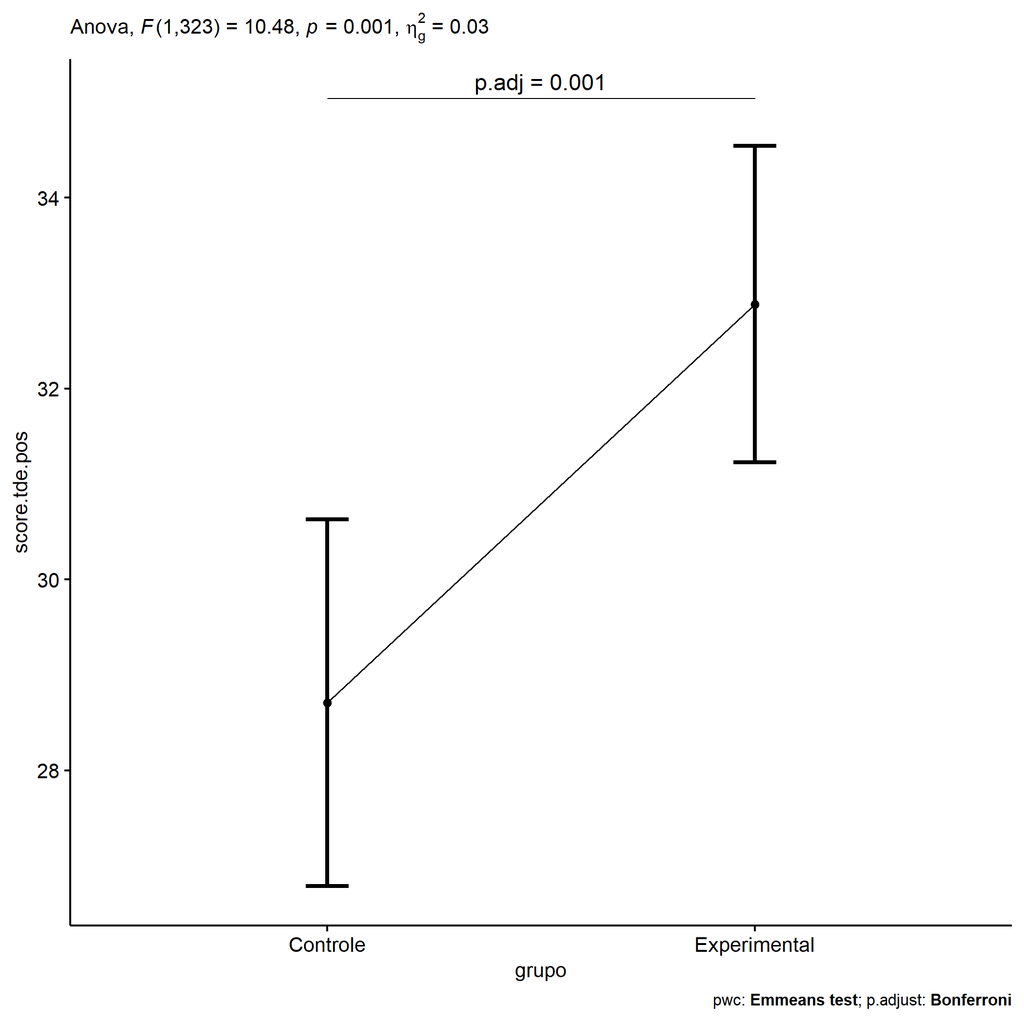

```r
if (!is.null(nrow(plots[["grupo"]]$data)))
  plots[["grupo"]] + ggplot2::scale_color_manual(values = color[["grupo"]])
```

```r
plots <- oneWayAncovaBoxPlots(
  wdat, "score.tde.pos", "grupo", aov, pwc, covar = "score.tde.pre",
  theme = "classic", color = color[["grupo"]],
  subtitle = which(aov$Effect == "grupo"))
```

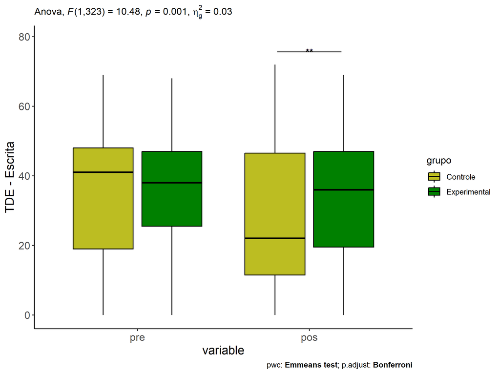

```r
if (length(unique(wdat[["grupo"]])) > 1)
  plots[["grupo"]] + ggplot2::ylab("TDE - Escrita") + ggplot2::scale_x_discrete(labels=c('pre', 'pos'))
```

```r
if (length(unique(wdat.long[["grupo"]])) > 1)
  plots <- oneWayAncovaBoxPlots(
    wdat.long, "score.tde", "grupo", aov, pwc.long, pre.post = "time",
    theme = "classic", color = color$prepost)
```

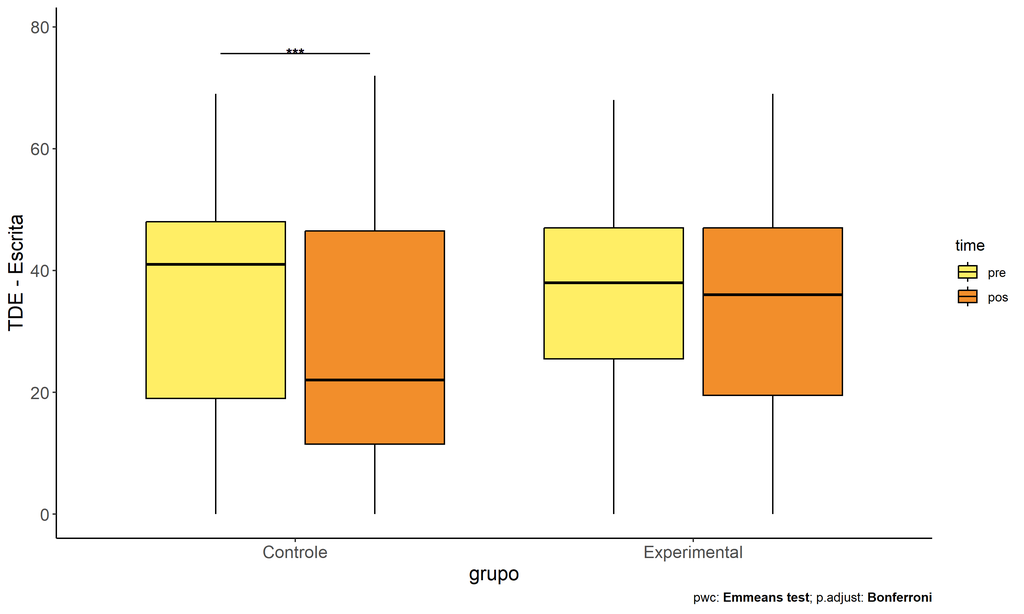

```r
if (length(unique(wdat.long[["grupo"]])) > 1)
  plots[["grupo"]] + ggplot2::ylab("TDE - Escrita")
```

### Checking linearity assumption

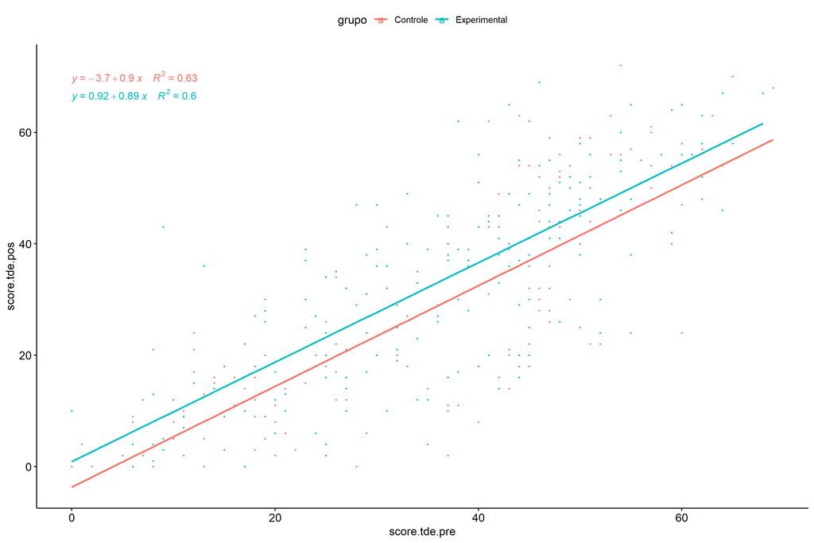

```r
ggscatter(wdat, x = "score.tde.pre", y = "score.tde.pos", size = 0.5,
          color = "grupo", add = "reg.line")+
  stat_regline_equation(
    aes(label =  paste(..eq.label.., ..rr.label.., sep = "~~~~"), color = grupo)
  )
```

### Checking normality and homogeneity

```r
res <- augment(lm(score.tde.pos ~ score.tde.pre + grupo, data = wdat))
```

```r
shapiro_test(res$.resid)
```

```
## # A tibble: 1 × 3
##   variable   statistic p.value
##   <chr>          <dbl>   <dbl>
## 1 res$.resid     0.993   0.112
```

```r
levene_test(res, .resid ~ grupo)
```

```
## # A tibble: 1 × 4
##     df1   df2 statistic      p
##   <int> <int>     <dbl>  <dbl>
## 1     1   324      4.06 0.0448
```

# ANCOVA and Pairwise for two factors **grupo:Sexo**

## Without remove non-normal data

```r
pdat = remove_group_data(dat[!is.na(dat[["grupo"]]) & !is.na(dat[["Sexo"]]),], "score.tde.pos", c("grupo","Sexo"))

pdat.long <- rbind(pdat[,c("id","grupo","Sexo")], pdat[,c("id","grupo","Sexo")])
pdat.long[["time"]] <- c(rep("pre", nrow(pdat)), rep("pos", nrow(pdat)))
pdat.long[["time"]] <- factor(pdat.long[["time"]], c("pre","pos"))
pdat.long[["score.tde"]] <- c(pdat[["score.tde.pre"]], pdat[["score.tde.pos"]])

aov = anova_test(pdat, score.tde.pos ~ score.tde.pre + grupo*Sexo)
laov[["grupo:Sexo"]] <- get_anova_table(aov)
```

```r
pwcs <- list()
pwcs[["Sexo"]] <- emmeans_test(
  group_by(pdat, grupo), score.tde.pos ~ Sexo,
  covariate = score.tde.pre, p.adjust.method = "bonferroni")
pwcs[["grupo"]] <- emmeans_test(
  group_by(pdat, Sexo), score.tde.pos ~ grupo,
  covariate = score.tde.pre, p.adjust.method = "bonferroni")

pwc <- plyr::rbind.fill(pwcs[["grupo"]], pwcs[["Sexo"]])
pwc <- pwc[,c("grupo","Sexo", colnames(pwc)[!colnames(pwc) %in% c("grupo","Sexo")])]
```

```r
pwc.long <- emmeans_test(dplyr::group_by_at(pdat.long, c("grupo","Sexo")),
                         score.tde ~ time,
                         p.adjust.method = "bonferroni")
lpwc[["grupo:Sexo"]] <- plyr::rbind.fill(pwc, pwc.long)
```

```r
ds <- get.descriptives(pdat, "score.tde.pos", c("grupo","Sexo"), covar = "score.tde.pre")
ds <- merge(ds[ds$variable != "score.tde.pre",],
            ds[ds$variable == "score.tde.pre", !colnames(ds) %in% c("variable")],
            by = c("grupo","Sexo"), all.x = T, suffixes = c("", ".score.tde.pre"))
ds <- merge(get_emmeans(pwcs[["grupo"]]), ds, by = c("grupo","Sexo"), suffixes = c(".emms", ""))
ds <- ds[,c("grupo","Sexo","n","mean.score.tde.pre","se.score.tde.pre","mean","se","emmean","se.emms")]

colnames(ds) <- c("grupo","Sexo", "N", paste0(c("M","SE")," (pre)"),
                  paste0(c("M","SE"), " (unadj)"), paste0(c("M", "SE"), " (adj)"))

lemms[["grupo:Sexo"]] <- ds
```

## Computing ANCOVA and PairWise After removing non-normal data (OK)

```r
wdat = pdat

res = residuals(lm(score.tde.pos ~ score.tde.pre + grupo*Sexo, data = wdat))
non.normal = getNonNormal(res, wdat$id, plimit = 0.05)

wdat = wdat[!wdat$id %in% non.normal,]

wdat.long <- rbind(wdat[,c("id","grupo","Sexo")], wdat[,c("id","grupo","Sexo")])
wdat.long[["time"]] <- c(rep("pre", nrow(wdat)), rep("pos", nrow(wdat)))
wdat.long[["time"]] <- factor(wdat.long[["time"]], c("pre","pos"))
wdat.long[["score.tde"]] <- c(wdat[["score.tde.pre"]], wdat[["score.tde.pos"]])


ldat[["grupo:Sexo"]] = wdat

(non.normal)
```

```
## [1] "P984" "P962"
```

```r
aov = anova_test(wdat, score.tde.pos ~ score.tde.pre + grupo*Sexo)
laov[["grupo:Sexo"]] <- merge(get_anova_table(aov), laov[["grupo:Sexo"]], by="Effect", suffixes = c("","'"))

(df = get_anova_table(aov))
```

```
## ANOVA Table (type II tests)
##
##          Effect DFn DFd       F        p p<.05   ges
## 1 score.tde.pre   1 321 513.541 1.43e-68     * 0.615
## 2         grupo   1 321  10.961 1.00e-03     * 0.033
## 3          Sexo   1 321   0.627 4.29e-01       0.002
## 4    grupo:Sexo   1 321   3.002 8.40e-02       0.009
```

| Effect | DFn | DFd | F | p | p<.05 | ges |
| --- | --- | --- | --- | --- | --- | --- |
| score.tde.pre | 1 | 321 | 513.541 | 0.000 | * | 0.615 |
| grupo | 1 | 321 | 10.961 | 0.001 | * | 0.033 |
| Sexo | 1 | 321 | 0.627 | 0.429 |  | 0.002 |
| grupo:Sexo | 1 | 321 | 3.002 | 0.084 |  | 0.009 |

```r
pwcs <- list()
pwcs[["Sexo"]] <- emmeans_test(
  group_by(wdat, grupo), score.tde.pos ~ Sexo,
  covariate = score.tde.pre, p.adjust.method = "bonferroni")
pwcs[["grupo"]] <- emmeans_test(
  group_by(wdat, Sexo), score.tde.pos ~ grupo,
  covariate = score.tde.pre, p.adjust.method = "bonferroni")

pwc <- plyr::rbind.fill(pwcs[["grupo"]], pwcs[["Sexo"]])
pwc <- pwc[,c("grupo","Sexo", colnames(pwc)[!colnames(pwc) %in% c("grupo","Sexo")])]
```

| grupo | Sexo | term | .y. | group1 | group2 | df | statistic | p | p.adj | p.adj.signif |
| --- | --- | --- | --- | --- | --- | --- | --- | --- | --- | --- |
|  | F | score.tde.pre*grupo | score.tde.pos | Controle | Experimental | 321 | -3.597 | 0.000 | 0.000 | *** |
|  | M | score.tde.pre*grupo | score.tde.pos | Controle | Experimental | 321 | -1.011 | 0.313 | 0.313 | ns |
| Controle |  | score.tde.pre*Sexo | score.tde.pos | F | M | 321 | -0.803 | 0.423 | 0.423 | ns |
| Experimental |  | score.tde.pre*Sexo | score.tde.pos | F | M | 321 | 1.721 | 0.086 | 0.086 | ns |

```r
pwc.long <- emmeans_test(dplyr::group_by_at(wdat.long, c("grupo","Sexo")),
                         score.tde ~ time,
                         p.adjust.method = "bonferroni")
lpwc[["grupo:Sexo"]] <- merge(plyr::rbind.fill(pwc, pwc.long), lpwc[["grupo:Sexo"]], by=c("grupo","Sexo","term",".y.","group1","group2"), suffixes = c("","'"))
```

| grupo | Sexo | term | .y. | group1 | group2 | df | statistic | p | p.adj | p.adj.signif |
| --- | --- | --- | --- | --- | --- | --- | --- | --- | --- | --- |
| Controle | F | time | score.tde | pre | pos | 644 | 2.905 | 0.004 | 0.004 | ** |
| Controle | M | time | score.tde | pre | pos | 644 | 1.807 | 0.071 | 0.071 | ns |
| Experimental | F | time | score.tde | pre | pos | 644 | 0.618 | 0.537 | 0.537 | ns |
| Experimental | M | time | score.tde | pre | pos | 644 | 1.730 | 0.084 | 0.084 | ns |

```r
ds <- get.descriptives(wdat, "score.tde.pos", c("grupo","Sexo"), covar = "score.tde.pre")
ds <- merge(ds[ds$variable != "score.tde.pre",],
            ds[ds$variable == "score.tde.pre", !colnames(ds) %in% c("variable")],
            by = c("grupo","Sexo"), all.x = T, suffixes = c("", ".score.tde.pre"))
ds <- merge(get_emmeans(pwcs[["grupo"]]), ds, by = c("grupo","Sexo"), suffixes = c(".emms", ""))
ds <- ds[,c("grupo","Sexo","n","mean.score.tde.pre","se.score.tde.pre","mean","se","emmean","se.emms")]

colnames(ds) <- c("grupo","Sexo", "N", paste0(c("M","SE")," (pre)"),
                  paste0(c("M","SE"), " (unadj)"), paste0(c("M", "SE"), " (adj)"))

lemms[["grupo:Sexo"]] <- merge(ds, lemms[["grupo:Sexo"]], by=c("grupo","Sexo"), suffixes = c("","'"))
```

| grupo | Sexo | N | M (pre) | SE (pre) | M (unadj) | SE (unadj) | M (adj) | SE (adj) |
| --- | --- | --- | --- | --- | --- | --- | --- | --- |
| Controle | F | 79 | 37.873 | 1.895 | 29.861 | 2.321 | 28.022 | 1.293 |
| Controle | M | 60 | 30.917 | 2.410 | 25.200 | 2.558 | 29.615 | 1.494 |
| Experimental | F | 88 | 37.841 | 1.480 | 36.227 | 1.739 | 34.418 | 1.225 |
| Experimental | M | 99 | 35.384 | 1.579 | 31.121 | 1.768 | 31.521 | 1.153 |

### Plots for ancova

```r
plots <- twoWayAncovaPlots(
  wdat, "score.tde.pos", c("grupo","Sexo"), aov, pwcs, addParam = c("mean_se"),
  font.label.size=10, step.increase=0.05, p.label="p.adj",
  subtitle = which(aov$Effect == "grupo:Sexo"))
```

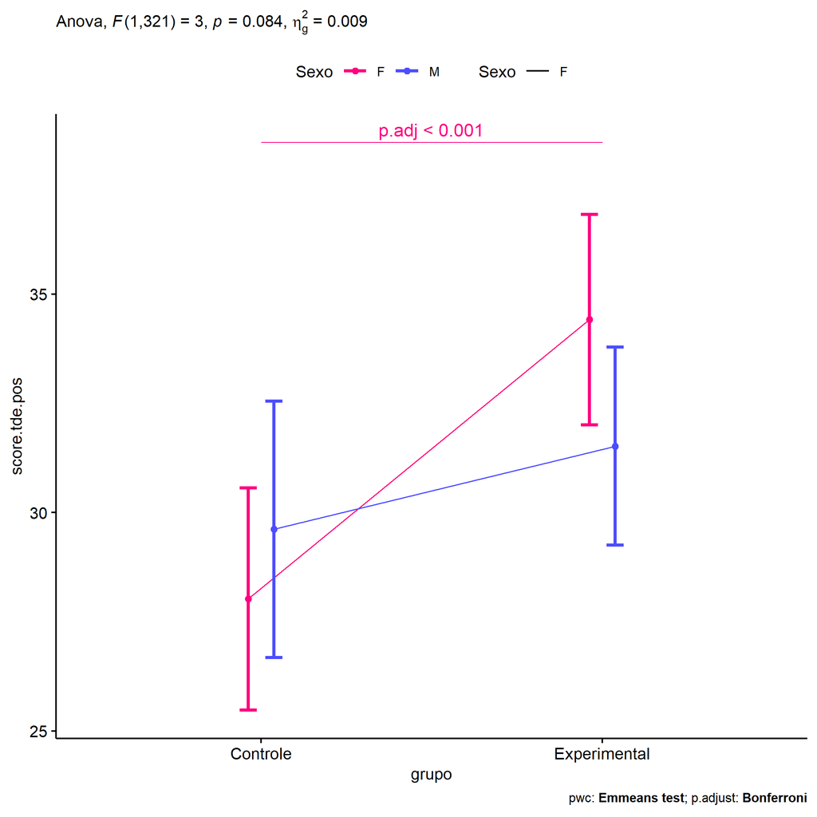

```r
if (!is.null(plots[["grupo"]]))
  plots[["grupo"]] + ggplot2::scale_color_manual(values = color[["Sexo"]])
```

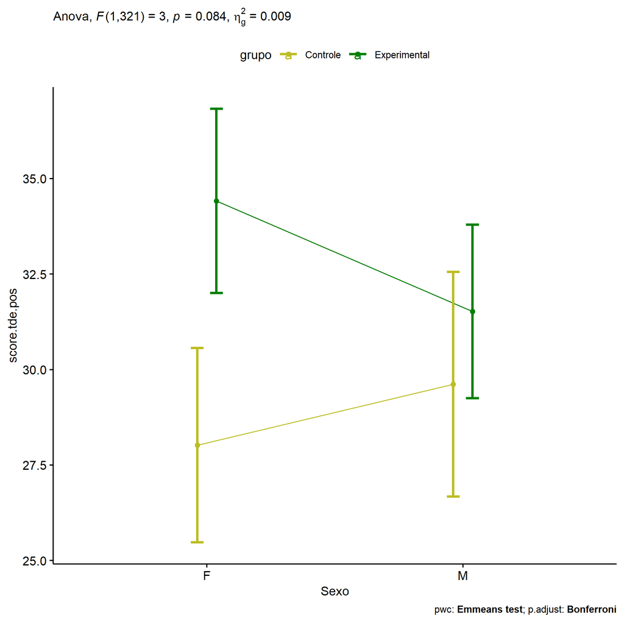

```r
if (!is.null(plots[["Sexo"]]))
  plots[["Sexo"]] + ggplot2::scale_color_manual(values = color[["grupo"]])
```

```r
plots <- twoWayAncovaBoxPlots(
  wdat, "score.tde.pos", c("grupo","Sexo"), aov, pwcs, covar = "score.tde.pre",
  theme = "classic", color = color[["grupo:Sexo"]],
  subtitle = which(aov$Effect == "grupo:Sexo"))
```

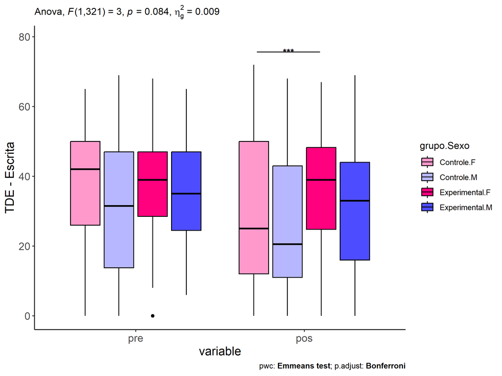

```r
plots[["grupo:Sexo"]] + ggplot2::ylab("TDE - Escrita") + ggplot2::scale_x_discrete(labels=c('pre', 'pos'))
```

```r
plots <- twoWayAncovaBoxPlots(
  wdat.long, "score.tde", c("grupo","Sexo"), aov, pwc.long, pre.post = "time",
  theme = "classic", color = color$prepost)
```

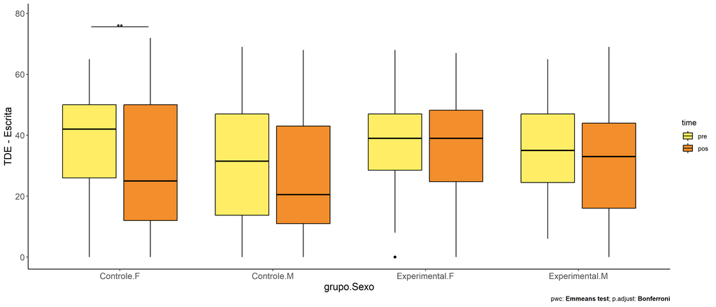

```r
plots[["grupo:Sexo"]] + ggplot2::ylab("TDE - Escrita")
```

### Checking linearity assumption

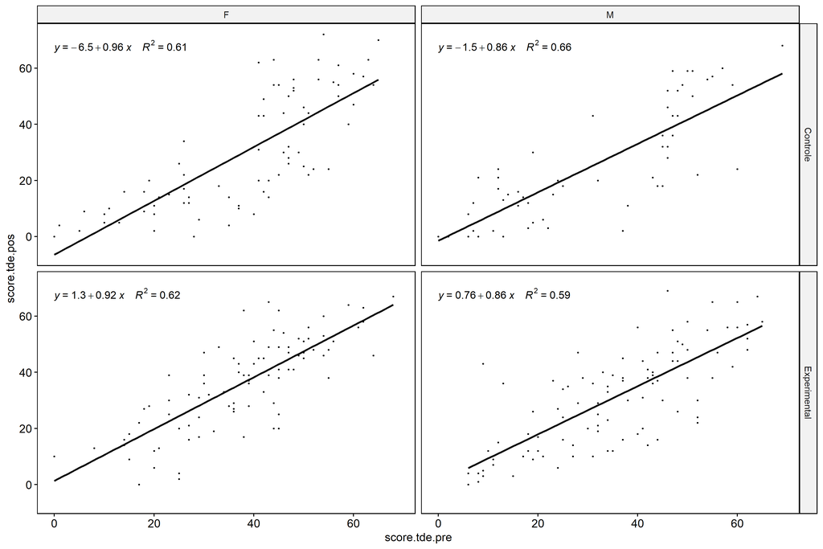

```r
ggscatter(wdat, x = "score.tde.pre", y = "score.tde.pos", size = 0.5,
          facet.by = c("grupo","Sexo"), add = "reg.line")+
  stat_regline_equation(
    aes(label =  paste(..eq.label.., ..rr.label.., sep = "~~~~"))
  )
```

### Checking normality and homogeneity

```r
res <- augment(lm(score.tde.pos ~ score.tde.pre + grupo*Sexo, data = wdat))
```

```r
shapiro_test(res$.resid)
```

```
## # A tibble: 1 × 3
##   variable   statistic p.value
##   <chr>          <dbl>   <dbl>
## 1 res$.resid     0.993   0.163
```

```r
levene_test(res, .resid ~ grupo*Sexo)
```

```
## # A tibble: 1 × 4
##     df1   df2 statistic      p
##   <int> <int>     <dbl>  <dbl>
## 1     3   322      2.30 0.0777
```

# ANCOVA and Pairwise for two factors **grupo:Zona**

## Without remove non-normal data

```r
pdat = remove_group_data(dat[!is.na(dat[["grupo"]]) & !is.na(dat[["Zona"]]),], "score.tde.pos", c("grupo","Zona"))

pdat.long <- rbind(pdat[,c("id","grupo","Zona")], pdat[,c("id","grupo","Zona")])
pdat.long[["time"]] <- c(rep("pre", nrow(pdat)), rep("pos", nrow(pdat)))
pdat.long[["time"]] <- factor(pdat.long[["time"]], c("pre","pos"))
pdat.long[["score.tde"]] <- c(pdat[["score.tde.pre"]], pdat[["score.tde.pos"]])

aov = anova_test(pdat, score.tde.pos ~ score.tde.pre + grupo*Zona)
laov[["grupo:Zona"]] <- get_anova_table(aov)
```

```r
pwcs <- list()
pwcs[["Zona"]] <- emmeans_test(
  group_by(pdat, grupo), score.tde.pos ~ Zona,
  covariate = score.tde.pre, p.adjust.method = "bonferroni")
pwcs[["grupo"]] <- emmeans_test(
  group_by(pdat, Zona), score.tde.pos ~ grupo,
  covariate = score.tde.pre, p.adjust.method = "bonferroni")

pwc <- plyr::rbind.fill(pwcs[["grupo"]], pwcs[["Zona"]])
pwc <- pwc[,c("grupo","Zona", colnames(pwc)[!colnames(pwc) %in% c("grupo","Zona")])]
```

```r
pwc.long <- emmeans_test(dplyr::group_by_at(pdat.long, c("grupo","Zona")),
                         score.tde ~ time,
                         p.adjust.method = "bonferroni")
lpwc[["grupo:Zona"]] <- plyr::rbind.fill(pwc, pwc.long)
```

```r
ds <- get.descriptives(pdat, "score.tde.pos", c("grupo","Zona"), covar = "score.tde.pre")
ds <- merge(ds[ds$variable != "score.tde.pre",],
            ds[ds$variable == "score.tde.pre", !colnames(ds) %in% c("variable")],
            by = c("grupo","Zona"), all.x = T, suffixes = c("", ".score.tde.pre"))
ds <- merge(get_emmeans(pwcs[["grupo"]]), ds, by = c("grupo","Zona"), suffixes = c(".emms", ""))
ds <- ds[,c("grupo","Zona","n","mean.score.tde.pre","se.score.tde.pre","mean","se","emmean","se.emms")]

colnames(ds) <- c("grupo","Zona", "N", paste0(c("M","SE")," (pre)"),
                  paste0(c("M","SE"), " (unadj)"), paste0(c("M", "SE"), " (adj)"))

lemms[["grupo:Zona"]] <- ds
```

## Computing ANCOVA and PairWise After removing non-normal data (OK)

```r
wdat = pdat

res = residuals(lm(score.tde.pos ~ score.tde.pre + grupo*Zona, data = wdat))
non.normal = getNonNormal(res, wdat$id, plimit = 0.05)

wdat = wdat[!wdat$id %in% non.normal,]

wdat.long <- rbind(wdat[,c("id","grupo","Zona")], wdat[,c("id","grupo","Zona")])
wdat.long[["time"]] <- c(rep("pre", nrow(wdat)), rep("pos", nrow(wdat)))
wdat.long[["time"]] <- factor(wdat.long[["time"]], c("pre","pos"))
wdat.long[["score.tde"]] <- c(wdat[["score.tde.pre"]], wdat[["score.tde.pos"]])


ldat[["grupo:Zona"]] = wdat

(non.normal)
```

```
## [1] "P962"
```

```r
aov = anova_test(wdat, score.tde.pos ~ score.tde.pre + grupo*Zona)
laov[["grupo:Zona"]] <- merge(get_anova_table(aov), laov[["grupo:Zona"]], by="Effect", suffixes = c("","'"))

(df = get_anova_table(aov))
```

```
## ANOVA Table (type II tests)
##
##          Effect DFn DFd       F        p p<.05   ges
## 1 score.tde.pre   1 280 513.580 2.70e-65     * 0.647
## 2         grupo   1 280   6.492 1.10e-02     * 0.023
## 3          Zona   1 280  26.275 5.53e-07     * 0.086
## 4    grupo:Zona   1 280  15.871 8.65e-05     * 0.054
```

| Effect | DFn | DFd | F | p | p<.05 | ges |
| --- | --- | --- | --- | --- | --- | --- |
| score.tde.pre | 1 | 280 | 513.580 | 0.000 | * | 0.647 |
| grupo | 1 | 280 | 6.492 | 0.011 | * | 0.023 |
| Zona | 1 | 280 | 26.275 | 0.000 | * | 0.086 |
| grupo:Zona | 1 | 280 | 15.871 | 0.000 | * | 0.054 |

```r
pwcs <- list()
pwcs[["Zona"]] <- emmeans_test(
  group_by(wdat, grupo), score.tde.pos ~ Zona,
  covariate = score.tde.pre, p.adjust.method = "bonferroni")
pwcs[["grupo"]] <- emmeans_test(
  group_by(wdat, Zona), score.tde.pos ~ grupo,
  covariate = score.tde.pre, p.adjust.method = "bonferroni")

pwc <- plyr::rbind.fill(pwcs[["grupo"]], pwcs[["Zona"]])
pwc <- pwc[,c("grupo","Zona", colnames(pwc)[!colnames(pwc) %in% c("grupo","Zona")])]
```

| grupo | Zona | term | .y. | group1 | group2 | df | statistic | p | p.adj | p.adj.signif |
| --- | --- | --- | --- | --- | --- | --- | --- | --- | --- | --- |
|  | Rural | score.tde.pre*grupo | score.tde.pos | Controle | Experimental | 280 | 0.796 | 0.426 | 0.426 | ns |
|  | Urbana | score.tde.pre*grupo | score.tde.pos | Controle | Experimental | 280 | -4.660 | 0.000 | 0.000 | **** |
| Controle |  | score.tde.pre*Zona | score.tde.pos | Rural | Urbana | 280 | 6.372 | 0.000 | 0.000 | **** |
| Experimental |  | score.tde.pre*Zona | score.tde.pos | Rural | Urbana | 280 | 1.263 | 0.208 | 0.208 | ns |

```r
pwc.long <- emmeans_test(dplyr::group_by_at(wdat.long, c("grupo","Zona")),
                         score.tde ~ time,
                         p.adjust.method = "bonferroni")
lpwc[["grupo:Zona"]] <- merge(plyr::rbind.fill(pwc, pwc.long), lpwc[["grupo:Zona"]], by=c("grupo","Zona","term",".y.","group1","group2"), suffixes = c("","'"))
```

| grupo | Zona | term | .y. | group1 | group2 | df | statistic | p | p.adj | p.adj.signif |
| --- | --- | --- | --- | --- | --- | --- | --- | --- | --- | --- |
| Controle | Rural | time | score.tde | pre | pos | 562 | 0.118 | 0.906 | 0.906 | ns |
| Controle | Urbana | time | score.tde | pre | pos | 562 | 3.989 | 0.000 | 0.000 | **** |
| Experimental | Rural | time | score.tde | pre | pos | 562 | 0.716 | 0.474 | 0.474 | ns |
| Experimental | Urbana | time | score.tde | pre | pos | 562 | 1.528 | 0.127 | 0.127 | ns |

```r
ds <- get.descriptives(wdat, "score.tde.pos", c("grupo","Zona"), covar = "score.tde.pre")
ds <- merge(ds[ds$variable != "score.tde.pre",],
            ds[ds$variable == "score.tde.pre", !colnames(ds) %in% c("variable")],
            by = c("grupo","Zona"), all.x = T, suffixes = c("", ".score.tde.pre"))
ds <- merge(get_emmeans(pwcs[["grupo"]]), ds, by = c("grupo","Zona"), suffixes = c(".emms", ""))
ds <- ds[,c("grupo","Zona","n","mean.score.tde.pre","se.score.tde.pre","mean","se","emmean","se.emms")]

colnames(ds) <- c("grupo","Zona", "N", paste0(c("M","SE")," (pre)"),
                  paste0(c("M","SE"), " (unadj)"), paste0(c("M", "SE"), " (adj)"))

lemms[["grupo:Zona"]] <- merge(ds, lemms[["grupo:Zona"]], by=c("grupo","Zona"), suffixes = c("","'"))
```

| grupo | Zona | N | M (pre) | SE (pre) | M (unadj) | SE (unadj) | M (adj) | SE (adj) |
| --- | --- | --- | --- | --- | --- | --- | --- | --- |
| Controle | Rural | 68 | 33.912 | 2.347 | 33.559 | 2.684 | 35.363 | 1.339 |
| Controle | Urbana | 55 | 36.036 | 2.133 | 22.745 | 2.374 | 22.613 | 1.486 |
| Experimental | Rural | 87 | 35.287 | 1.550 | 33.391 | 1.846 | 33.941 | 1.182 |
| Experimental | Urbana | 75 | 38.280 | 1.828 | 33.920 | 1.962 | 31.743 | 1.277 |

### Plots for ancova

```r
plots <- twoWayAncovaPlots(
  wdat, "score.tde.pos", c("grupo","Zona"), aov, pwcs, addParam = c("mean_se"),
  font.label.size=10, step.increase=0.05, p.label="p.adj",
  subtitle = which(aov$Effect == "grupo:Zona"))
```

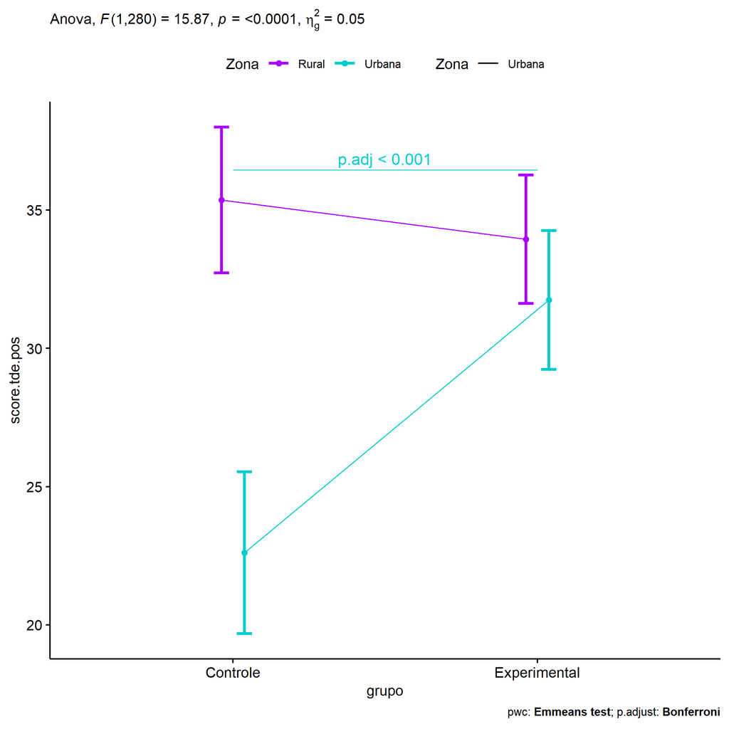

```r
if (!is.null(plots[["grupo"]]))
  plots[["grupo"]] + ggplot2::scale_color_manual(values = color[["Zona"]])
```

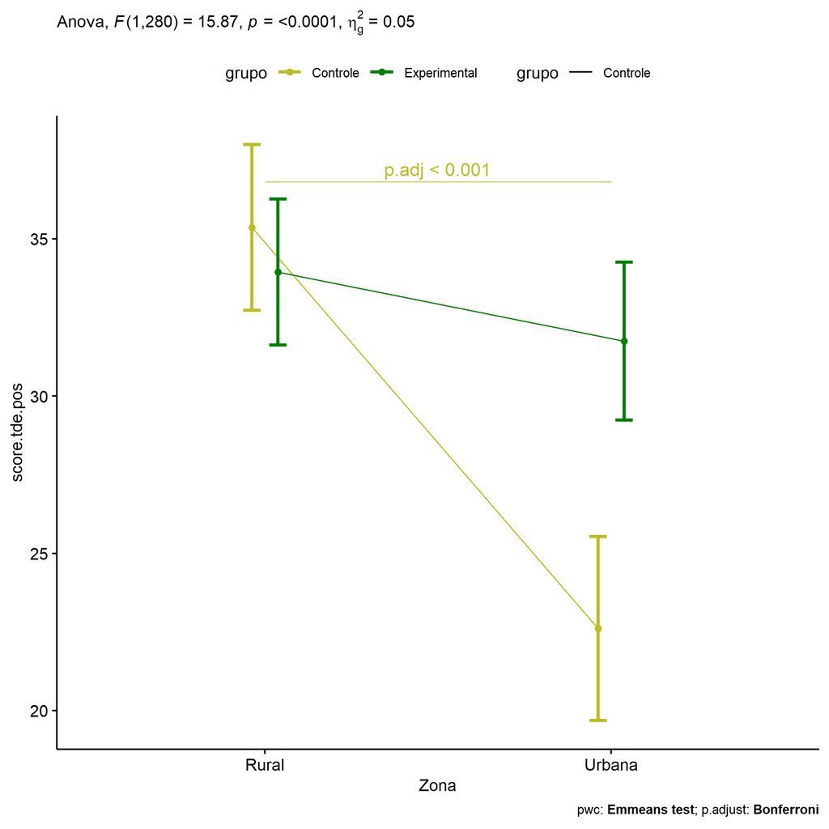

```r
if (!is.null(plots[["Zona"]]))
  plots[["Zona"]] + ggplot2::scale_color_manual(values = color[["grupo"]])
```

```r
plots <- twoWayAncovaBoxPlots(
  wdat, "score.tde.pos", c("grupo","Zona"), aov, pwcs, covar = "score.tde.pre",
  theme = "classic", color = color[["grupo:Zona"]],
  subtitle = which(aov$Effect == "grupo:Zona"))
```

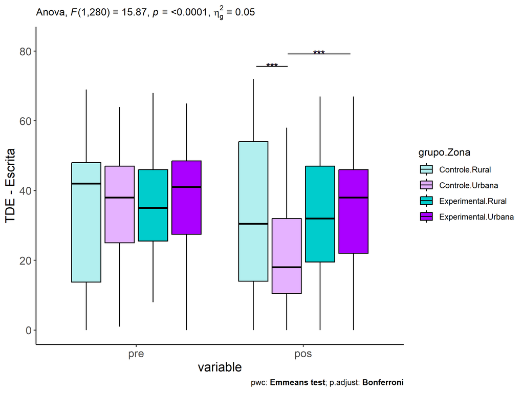

```r
plots[["grupo:Zona"]] + ggplot2::ylab("TDE - Escrita") + ggplot2::scale_x_discrete(labels=c('pre', 'pos'))
```

```r
plots <- twoWayAncovaBoxPlots(
  wdat.long, "score.tde", c("grupo","Zona"), aov, pwc.long, pre.post = "time",
  theme = "classic", color = color$prepost)
```

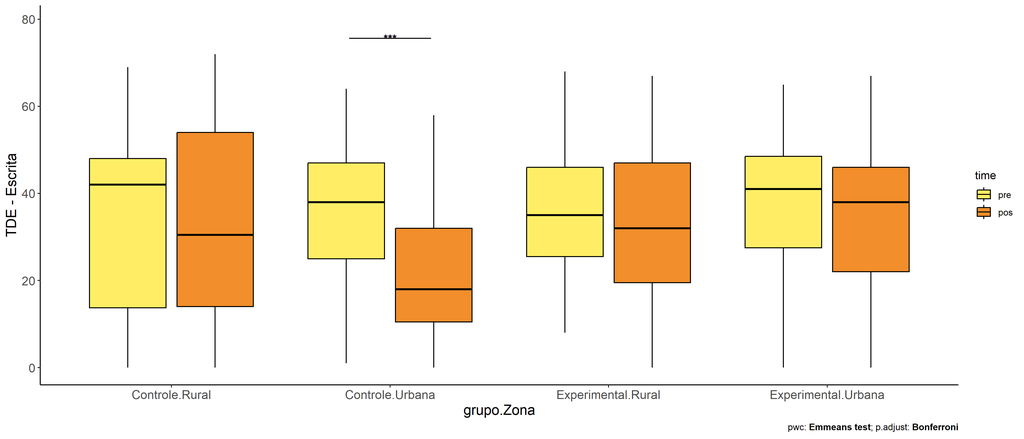

```r
plots[["grupo:Zona"]] + ggplot2::ylab("TDE - Escrita")
```

### Checking linearity assumption

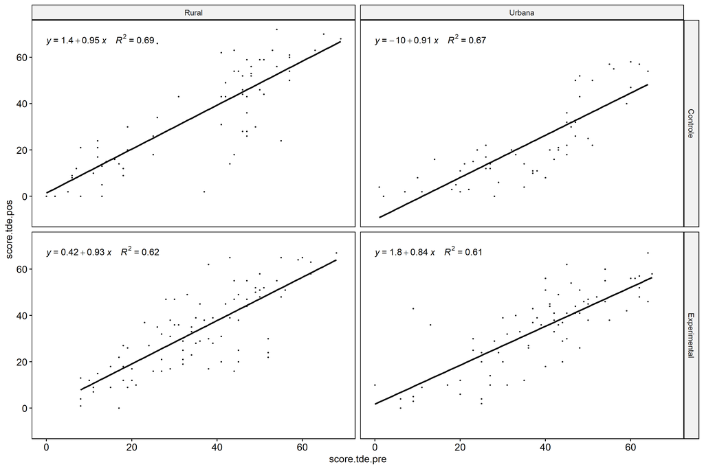

```r
ggscatter(wdat, x = "score.tde.pre", y = "score.tde.pos", size = 0.5,
          facet.by = c("grupo","Zona"), add = "reg.line")+
  stat_regline_equation(
    aes(label =  paste(..eq.label.., ..rr.label.., sep = "~~~~"))
  )
```

### Checking normality and homogeneity

```r
res <- augment(lm(score.tde.pos ~ score.tde.pre + grupo*Zona, data = wdat))
```

```r
shapiro_test(res$.resid)
```

```
## # A tibble: 1 × 3
##   variable   statistic p.value
##   <chr>          <dbl>   <dbl>
## 1 res$.resid     0.992   0.105
```

```r
levene_test(res, .resid ~ grupo*Zona)
```

```
## # A tibble: 1 × 4
##     df1   df2 statistic     p
##   <int> <int>     <dbl> <dbl>
## 1     3   281     0.324 0.808
```

# ANCOVA and Pairwise for two factors **grupo:Cor.Raca**

## Without remove non-normal data

```r
pdat = remove_group_data(dat[!is.na(dat[["grupo"]]) & !is.na(dat[["Cor.Raca"]]),], "score.tde.pos", c("grupo","Cor.Raca"))
pdat.long <- rbind(pdat[,c("id","grupo","Cor.Raca")], pdat[,c("id","grupo","Cor.Raca")])
pdat.long[["time"]] <- c(rep("pre", nrow(pdat)), rep("pos", nrow(pdat)))
pdat.long[["time"]] <- factor(pdat.long[["time"]], c("pre","pos"))
pdat.long[["score.tde"]] <- c(pdat[["score.tde.pre"]], pdat[["score.tde.pos"]])

aov = anova_test(pdat, score.tde.pos ~ score.tde.pre + grupo*Cor.Raca)
laov[["grupo:Cor.Raca"]] <- get_anova_table(aov)
```

```r
pwcs <- list()
pwcs[["Cor.Raca"]] <- emmeans_test(
  group_by(pdat, grupo), score.tde.pos ~ Cor.Raca,
  covariate = score.tde.pre, p.adjust.method = "bonferroni")
pwcs[["grupo"]] <- emmeans_test(
  group_by(pdat, Cor.Raca), score.tde.pos ~ grupo,
  covariate = score.tde.pre, p.adjust.method = "bonferroni")

pwc <- plyr::rbind.fill(pwcs[["grupo"]], pwcs[["Cor.Raca"]])
pwc <- pwc[,c("grupo","Cor.Raca", colnames(pwc)[!colnames(pwc) %in% c("grupo","Cor.Raca")])]
```

```r
pwc.long <- emmeans_test(dplyr::group_by_at(pdat.long, c("grupo","Cor.Raca")),
                         score.tde ~ time,
                         p.adjust.method = "bonferroni")
lpwc[["grupo:Cor.Raca"]] <- plyr::rbind.fill(pwc, pwc.long)
```

```r
ds <- get.descriptives(pdat, "score.tde.pos", c("grupo","Cor.Raca"), covar = "score.tde.pre")
ds <- merge(ds[ds$variable != "score.tde.pre",],
            ds[ds$variable == "score.tde.pre", !colnames(ds) %in% c("variable")],
            by = c("grupo","Cor.Raca"), all.x = T, suffixes = c("", ".score.tde.pre"))
ds <- merge(get_emmeans(pwcs[["grupo"]]), ds, by = c("grupo","Cor.Raca"), suffixes = c(".emms", ""))
ds <- ds[,c("grupo","Cor.Raca","n","mean.score.tde.pre","se.score.tde.pre","mean","se","emmean","se.emms")]

colnames(ds) <- c("grupo","Cor.Raca", "N", paste0(c("M","SE")," (pre)"),
                  paste0(c("M","SE"), " (unadj)"), paste0(c("M", "SE"), " (adj)"))

lemms[["grupo:Cor.Raca"]] <- ds
```

## Computing ANCOVA and PairWise After removing non-normal data (OK)

```r
wdat = pdat

res = residuals(lm(score.tde.pos ~ score.tde.pre + grupo*Cor.Raca, data = wdat))
non.normal = getNonNormal(res, wdat$id, plimit = 0.05)

wdat = wdat[!wdat$id %in% non.normal,]

wdat.long <- rbind(wdat[,c("id","grupo","Cor.Raca")], wdat[,c("id","grupo","Cor.Raca")])
wdat.long[["time"]] <- c(rep("pre", nrow(wdat)), rep("pos", nrow(wdat)))
wdat.long[["time"]] <- factor(wdat.long[["time"]], c("pre","pos"))
wdat.long[["score.tde"]] <- c(wdat[["score.tde.pre"]], wdat[["score.tde.pos"]])


ldat[["grupo:Cor.Raca"]] = wdat

(non.normal)
```

[output not shown]

```r
aov = anova_test(wdat, score.tde.pos ~ score.tde.pre + grupo*Cor.Raca)
laov[["grupo:Cor.Raca"]] <- merge(get_anova_table(aov), laov[["grupo:Cor.Raca"]], by="Effect", suffixes = c("","'"))

(df = get_anova_table(aov))
```

```
## ANOVA Table (type II tests)
##
##           Effect DFn DFd       F        p p<.05   ges
## 1  score.tde.pre   1 115 138.455 1.84e-21     * 0.546
## 2          grupo   1 115   5.026 2.70e-02     * 0.042
## 3       Cor.Raca   2 115   3.090 4.90e-02     * 0.051
## 4 grupo:Cor.Raca   1 115   2.944 8.90e-02       0.025
```

| Effect | DFn | DFd | F | p | p<.05 | ges |
| --- | --- | --- | --- | --- | --- | --- |
| score.tde.pre | 1 | 115 | 138.455 | 0.000 | * | 0.546 |
| grupo | 1 | 115 | 5.026 | 0.027 | * | 0.042 |
| Cor.Raca | 2 | 115 | 3.090 | 0.049 | * | 0.051 |
| grupo:Cor.Raca | 1 | 115 | 2.944 | 0.089 |  | 0.025 |

```r
pwcs <- list()
pwcs[["Cor.Raca"]] <- emmeans_test(
  group_by(wdat, grupo), score.tde.pos ~ Cor.Raca,
  covariate = score.tde.pre, p.adjust.method = "bonferroni")
pwcs[["grupo"]] <- emmeans_test(
  group_by(wdat, Cor.Raca), score.tde.pos ~ grupo,
  covariate = score.tde.pre, p.adjust.method = "bonferroni")

pwc <- plyr::rbind.fill(pwcs[["grupo"]], pwcs[["Cor.Raca"]])
pwc <- pwc[,c("grupo","Cor.Raca", colnames(pwc)[!colnames(pwc) %in% c("grupo","Cor.Raca")])]
```

| grupo | Cor.Raca | term | .y. | group1 | group2 | df | statistic | p | p.adj | p.adj.signif |
| --- | --- | --- | --- | --- | --- | --- | --- | --- | --- | --- |
|  | Branca | score.tde.pre*grupo | score.tde.pos | Controle | Experimental | 115 | -2.598 | 0.011 | 0.011 | * |
|  | Indígena | score.tde.pre*grupo | score.tde.pos | Controle | Experimental |  |  |  |  |  |
|  | Parda | score.tde.pre*grupo | score.tde.pos | Controle | Experimental | 115 | -1.097 | 0.275 | 0.275 | ns |
| Controle |  | score.tde.pre*Cor.Raca | score.tde.pos | Branca | Indígena | 115 | -2.605 | 0.010 | 0.031 | * |
| Controle |  | score.tde.pre*Cor.Raca | score.tde.pos | Branca | Parda | 115 | -0.842 | 0.402 | 1.000 | ns |
| Controle |  | score.tde.pre*Cor.Raca | score.tde.pos | Indígena | Parda | 115 | 2.215 | 0.029 | 0.086 | ns |
| Experimental |  | score.tde.pre*Cor.Raca | score.tde.pos | Branca | Indígena |  |  |  |  |  |
| Experimental |  | score.tde.pre*Cor.Raca | score.tde.pos | Branca | Parda | 115 | 1.521 | 0.131 | 0.131 | ns |
| Experimental |  | score.tde.pre*Cor.Raca | score.tde.pos | Indígena | Parda |  |  |  |  |  |

```r
pwc.long <- emmeans_test(dplyr::group_by_at(wdat.long, c("grupo","Cor.Raca")),
                         score.tde ~ time,
                         p.adjust.method = "bonferroni")
lpwc[["grupo:Cor.Raca"]] <- merge(plyr::rbind.fill(pwc, pwc.long), lpwc[["grupo:Cor.Raca"]], by=c("grupo","Cor.Raca","term",".y.","group1","group2"), suffixes = c("","'"))
```

| grupo | Cor.Raca | term | .y. | group1 | group2 | df | statistic | p | p.adj | p.adj.signif |
| --- | --- | --- | --- | --- | --- | --- | --- | --- | --- | --- |
| Controle | Branca | time | score.tde | pre | pos | 232 | 2.022 | 0.044 | 0.044 | * |
| Controle | Indígena | time | score.tde | pre | pos | 232 | -0.413 | 0.680 | 0.680 | ns |
| Controle | Parda | time | score.tde | pre | pos | 232 | 1.807 | 0.072 | 0.072 | ns |
| Experimental | Branca | time | score.tde | pre | pos | 232 | -0.333 | 0.740 | 0.740 | ns |
| Experimental | Indígena | time | score.tde | pre | pos |  |  |  |  |  |
| Experimental | Parda | time | score.tde | pre | pos | 232 | 1.164 | 0.246 | 0.246 | ns |

```r
ds <- get.descriptives(wdat, "score.tde.pos", c("grupo","Cor.Raca"), covar = "score.tde.pre")
ds <- merge(ds[ds$variable != "score.tde.pre",],
            ds[ds$variable == "score.tde.pre", !colnames(ds) %in% c("variable")],
            by = c("grupo","Cor.Raca"), all.x = T, suffixes = c("", ".score.tde.pre"))
ds <- merge(get_emmeans(pwcs[["grupo"]]), ds, by = c("grupo","Cor.Raca"), suffixes = c(".emms", ""))
ds <- ds[,c("grupo","Cor.Raca","n","mean.score.tde.pre","se.score.tde.pre","mean","se","emmean","se.emms")]

colnames(ds) <- c("grupo","Cor.Raca", "N", paste0(c("M","SE")," (pre)"),
                  paste0(c("M","SE"), " (unadj)"), paste0(c("M", "SE"), " (adj)"))

lemms[["grupo:Cor.Raca"]] <- merge(ds, lemms[["grupo:Cor.Raca"]], by=c("grupo","Cor.Raca"), suffixes = c("","'"))
```

| grupo | Cor.Raca | N | M (pre) | SE (pre) | M (unadj) | SE (unadj) | M (adj) | SE (adj) |
| --- | --- | --- | --- | --- | --- | --- | --- | --- |
| Controle | Branca | 21 | 39.095 | 2.872 | 28.190 | 3.536 | 24.667 | 2.787 |
| Controle | Indígena | 6 | 40.833 | 5.263 | 45.000 | 7.353 | 39.978 | 5.201 |
| Controle | Parda | 39 | 33.051 | 3.127 | 25.897 | 3.331 | 27.584 | 2.038 |
| Experimental | Branca | 10 | 33.400 | 4.568 | 36.000 | 4.455 | 37.386 | 4.016 |
| Experimental | Parda | 45 | 34.378 | 2.175 | 30.089 | 2.820 | 30.632 | 1.893 |